# Problem Set #2: Understanding Factors Affecting the Early Care and Education Workforce in the United States

Zachary Johnigan

# Data for Policy Analysis and Management

**Instructor:** Aida Pacheco-Applegate  
**Course:** SSAD 48500  
**Term:** Summer 2026

## Background

The mental health of early childhood educators is a critical component of a high-quality early care and education system (Murphy & Reid, 2025). Research has shown that educators’ psychological well-being affects not only their own work experiences but also children’s classroom environments, emotional development, and academic achievement (McLean & Connor, 2015; Oberle & Schonert-Reichl, 2016). In addition, educators with better mental health tend to have more positive interactions with children and report fewer behavioral challenges in their classrooms (Jeon et al., 2014; Kwon et al., 2019). Because early childhood experiences have lasting effects on children’s health, educational attainment, and future opportunities, understanding the factors associated with educator mental health is an important research and policy priority (Murphy & Reid, 2025).

In this problem set, you will examine factors associated with depression among staff working in center-based early care and education programs in the United States. Following the analytical approach of Murphy and Reid (2025), you will use data from the 2019 National Survey of Early Care and Education (NSECE) to apply the statistical techniques covered in class and investigate how educator characteristics are associated with depression. # 1. Set up working space and import packages

```r
# This cleans up everything in the "Environment" pane.
rm(list=ls())
options("error")
```

```r
options(lifecycle_disable_verbose_retirement = TRUE)
```

```r
# Import packages
package.list <- c("tidyverse")

# read the `package.list` for the list of packages we will be needing
# Check what packages are installed already
# If any of the packages in the c() list are not currently installed, install them.
# Note: Check the "Packages" tab to verify that they were installed. If they were not, then check the box and click "Install".
for (p in package.list){
  if (!p %in% installed.packages()[, "Package"]) install.packages(p)
  library(p, character.only=TRUE)
}
# Set up working directory

## check your directory
getwd()
```

```
## [1] "/home/zacharyjohnigan/UChicago_Student/2_Data_For_Policy_Analys_-_Mgmt/Problem_Sets/Problem_Set_2"
```

```r
## set up working directory
my_directory   <- "/home/zacharyjohnigan/UChicago_Student/2_Data_For_Policy_Analys_-_Mgmt/"
my_data        <- paste0(my_directory, "Data/")
output_dir     <- paste0(my_directory, "Problem_Sets/Problem_Set_2/")
```

# 2. Load dataset

```r
# Import NSECE 2019 workforce questionnnaire
load(paste0(my_data, "37941-0005-Data.rda"))
```

# 4. Basic cleaning of the data

```r
# Rename dataset
nsece_2019_wf <- da37941.0005
```

# Question 1 — Clean and Understand the Data (4 points)

Subset the NSECE dataset to include the following variables: - `WF9_WORK_WAGE` — hourly wage - `WF9_WORK_ROLE` — staff role - `WF9_CHAR_RACE` — race - `WF9_CHAR_EDUC` — highest level of education completed - `WF9_CHAR_YEAR_BORN` — staff’s birth year - `WF9_CESD7_TOT` — staff’s total score on CESD7 (depression) scale

> **Note:** `WF9_CESD7_TOT` measures the respondent’s overall level of depressive symptoms. Scores range from 0, indicating no signs of depression, to 21, indicating severe depressive symptoms. According to the NSECE User Guide (2019), a score of 8 or higher is the recommended cutoff for identifying individuals who may have major depressive disorder. For additional information about this measure, see page 220 of the NSECE User Guide (2019).

# Rename the variables using clear, descriptive names. Perform any data cleaning you consider necessary.

```r
# Subset the NSECE dataset and rename the variables
nsece_ps2 <-
  nsece_2019_wf %>%
  select(
    hourly_wage = WF9_WORK_WAGE,
    staff_role = WF9_WORK_ROLE,
    race = WF9_CHAR_RACE,
    education = WF9_CHAR_EDUC,
    birth_year = WF9_CHAR_YEAR_BORN,
    depression = WF9_CESD7_TOT
  )

#glimpse(nsece_ps2)
```

Create the following variables using the code below:

```r
# Create staff age and hourly wage categories
nsece_ps2_recode <-
  nsece_ps2 %>%
  mutate(
    staff_age = 2019 - birth_year,

    staff_age_new = case_when(
      staff_age >= 20 & staff_age <= 40 ~ "Between 20 and 40",
      staff_age >= 41 & staff_age <= 50 ~ "Between 41 and 50",
      staff_age >= 51 ~ "More than 51"
    ),

    staff_age_new = factor(
      staff_age_new,
      levels = c(
        "Between 20 and 40",
        "Between 41 and 50",
        "More than 51"
      ),
      labels = c(
        "Between 20 and 40",
        "Between 41 and 50",
        "More than 51"
      )
    ),

    hr_wage_new = case_when(
      hourly_wage <= 10 ~ "Less than $10",
      hourly_wage >= 11 & hourly_wage <= 20 ~ "Between $11 and $20",
      hourly_wage >= 21 & hourly_wage <= 30 ~ "Between $21 and $30",
      hourly_wage >= 31 ~ "More than $31"
    ),

    hr_wage_new = factor(
      hr_wage_new,
      levels = c(
        "Less than $10",
        "Between $11 and $20",
        "Between $21 and $30",
        "More than $31"
      ),
      labels = c(
        "Less than $10",
        "Between $11 and $20",
        "Between $21 and $30",
        "More than $31"
      )
    )
  )

# Examine newly created variables
class(nsece_ps2_recode$staff_age_new)
```

```
## [1] "factor"
```

```r
summary(nsece_ps2_recode$staff_age_new)
```

```
## Between 20 and 40 Between 41 and 50      More than 51              NA's
##              2449               895              1153               695
```

```r
class(nsece_ps2_recode$hr_wage_new)
```

```
## [1] "factor"
```

```r
summary(nsece_ps2_recode$hr_wage_new)
```

```
##       Less than $10 Between $11 and $20 Between $21 and $30       More than $31
##                1088                2359                 335                 209
##                NA's
##                1201
```

```r
# Export to CSV for easy viewing
write_csv(nsece_ps2_recode, "CSV_Files/nsece_ps2_recode.csv")
```

Using the variables **role, race, educational attainment, depression, staff age, and hourly wage** — including the new `staff_age_new` and `hr_wage_new` variables — complete the following tasks for **each variable**:

- Identify its level of measurement: **nominal, ordinal, or interval/ratio**.
- Indicate whether it is **discrete or continuous**.
- Present the appropriate **descriptive statistics, tables, or graphs**, including measures of **central tendency, dispersion, and shape** when applicable.
- **Describe and interpret** your findings.

> Full visualizations using `ggplot2` are not required.

## Q1 Analysis

### Staff Role

```r
# Variable type: Nominal + Discrete

# Frequency and percentage table
staff_role_table <-
  nsece_ps2_recode %>%
  count(staff_role) %>%
  mutate(proportion = (n / sum(n)) * 100)

staff_role_table
```

```
##                                 staff_role    n proportion
## 1            (1) Aide or assistant teacher 1611 31.0285054
## 2 (2) Teacher, instructor, or lead teacher 3079 59.3027735
## 3                   (3) Other/undetermined   18  0.3466872
## 4                                     <NA>  484  9.3220339
```

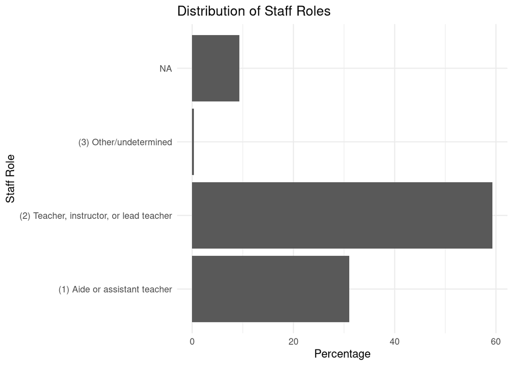

```r
ggplot(staff_role_table,
       aes(x = staff_role, y = proportion)) +
  geom_col() +
  coord_flip() +
  labs(
    title = "Distribution of Staff Roles",
    x = "Staff Role",
    y = "Percentage"
  ) +
  theme_minimal()
```

**Interpretation:** Staff role is a nominal, discrete variable because respondents are classified into distinct job categories that have no inherent ranking. Teachers, instructors, or lead teachers were the most common staff role (59.3%), followed by aides or assistant teachers (31.0%). Less than 1% (0.35%) were classified as other/undetermined, while 9.3% of observations were missing staff-role information. The frequency table and bar graph both show that teachers, instructors, or lead teachers make up the majority of respondents.

Because staff role is nominal, the mode is the appropriate measure of central tendency. The modal category is teacher, instructor, or lead teacher. Numerical measures such as the mean, median, standard deviation, and measures of distributional shape are not meaningful for this variable.

### Race

```r
# Variable type: Nominal + Discrete

# Frequency and percentage table
race_table <-
  nsece_ps2_recode %>%
  count(race) %>%
  mutate(proportion = (n / sum(n)) * 100)

race_table
```

```
##                                 race    n proportion
## 1                     (1) White Only 2825  54.410632
## 2 (2) Black or African American Only  991  19.087057
## 3                     (3) Asian Only  210   4.044684
## 4                          (8) Other  215   4.140986
## 5                               <NA>  951  18.316641
```

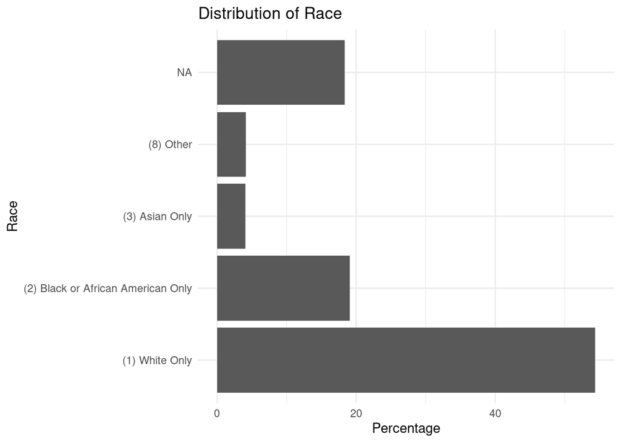

```r
ggplot(race_table,
       aes(x = race, y = proportion)) +
  geom_col() +
  coord_flip() +
  labs(
    title = "Distribution of Race",
    x = "Race",
    y = "Percentage"
  ) +
  theme_minimal()
```

**Interpretation:** Race is a nominal, discrete variable because respondents are classified into distinct racial categories that have no inherent ranking. White-only respondents were the largest group (54.4%), followed by Black or African American-only respondents (19.1%). Asian-only respondents accounted for 4.0%, and respondents classified as Other accounted for 4.1%. Approximately 18.3% of observations were missing race information.

Because race is nominal, the mode is the appropriate measure of central tendency. The modal category is White Only. Numerical measures such as the mean, median, standard deviation, and measures of distributional shape are not meaningful for this variable.

### Educational Attainment

```r
# Variable type: Ordinal + Discrete

# Frequency and percentage table
education_table <-
  nsece_ps2_recode %>%
  count(education) %>%
  mutate(proportion = (n / sum(n)) * 100)

education_table
```

```
##                               education    n proportion
## 1             (1) Less than High School   85   1.637134
## 2    (3) GED or high school equivalency  126   2.426810
## 3              (4) High school graduate  769  14.811248
## 4 (5) Some college credit but no degree 1279  24.634052
## 5         (6) Associate degree (AA, AS)  834  16.063174
## 6    (7) Bachelor's degree (BA, BS, AB) 1168  22.496148
## 7   (8) Graduate or professional degree  424   8.166410
## 8                                  <NA>  507   9.765023
```

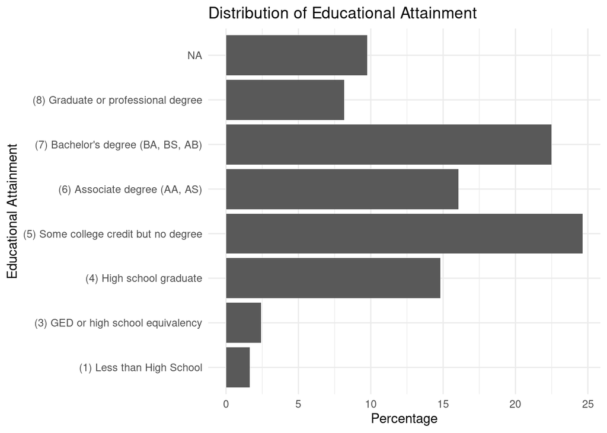

```r
ggplot(education_table,
       aes(x = education, y = proportion)) +
  geom_col() +
  coord_flip() +
  labs(
    title = "Distribution of Educational Attainment",
    x = "Educational Attainment",
    y = "Percentage"
  ) +
  theme_minimal()
```

# Examine ordering of education categories

```r
class(nsece_ps2_recode$education)
```

```
## [1] "factor"
```

```r
levels(nsece_ps2_recode$education)
```

```
## [1] "(1) Less than High School"
## [2] "(3) GED or high school equivalency"
## [3] "(4) High school graduate"
## [4] "(5) Some college credit but no degree"
## [5] "(6) Associate degree (AA, AS)"
## [6] "(7) Bachelor's degree (BA, BS, AB)"
## [7] "(8) Graduate or professional degree"
```

# Cumulative percentage to identify the median category

```r
education_median <-
  nsece_ps2_recode %>%
  filter(!is.na(education)) %>%
  count(education) %>%
  mutate(
    proportion = (n / sum(n)) * 100,
    cumulative_proportion = cumsum(proportion)
  )

education_median
```

```
##                               education    n proportion cumulative_proportion
## 1             (1) Less than High School   85   1.814301              1.814301
## 2    (3) GED or high school equivalency  126   2.689434              4.503735
## 3              (4) High school graduate  769  16.414088             20.917823
## 4 (5) Some college credit but no degree 1279  27.299893             48.217716
## 5         (6) Associate degree (AA, AS)  834  17.801494             66.019210
## 6    (7) Bachelor's degree (BA, BS, AB) 1168  24.930630             90.949840
## 7   (8) Graduate or professional degree  424   9.050160            100.000000
```

**Interpretation:** Educational attainment is an ordinal, discrete variable because respondents fall into distinct educational categories that have a meaningful order. Among respondents with valid education data, the most common category (mode) was some college credit but no degree (27.3%), followed by a bachelor’s degree (24.9%). The median category was associate degree (AA, AS) because the cumulative percentage first exceeded 50% at that category. Approximately 9.1% of respondents held a graduate or professional degree, while relatively few had less than a high school education (1.8%) or a GED/high school equivalency (2.7%).

Because educational attainment is ordinal rather than interval/ratio, the mean and standard deviation are not appropriate measures. The median, mode, frequency distribution, cumulative percentages, and bar graph appropriately describe its central tendency and distribution.

### Depression

```r
# Variable type: Interval/Ratio + Discrete

# Descriptive statistics
nsece_ps2_recode %>%
  summarise(
    n = sum(!is.na(depression)),
    missing = sum(is.na(depression)),
    mean = mean(depression, na.rm = TRUE),
    median = median(depression, na.rm = TRUE),
    sd = sd(depression, na.rm = TRUE),
    min = min(depression, na.rm = TRUE),
    max = max(depression, na.rm = TRUE),
    IQR = IQR(depression, na.rm = TRUE)
  )
```

```
##      n missing     mean median       sd min max IQR
## 1 4537     655 2.522636      1 3.219959   0  21   4
```

# Histogram of depression scores

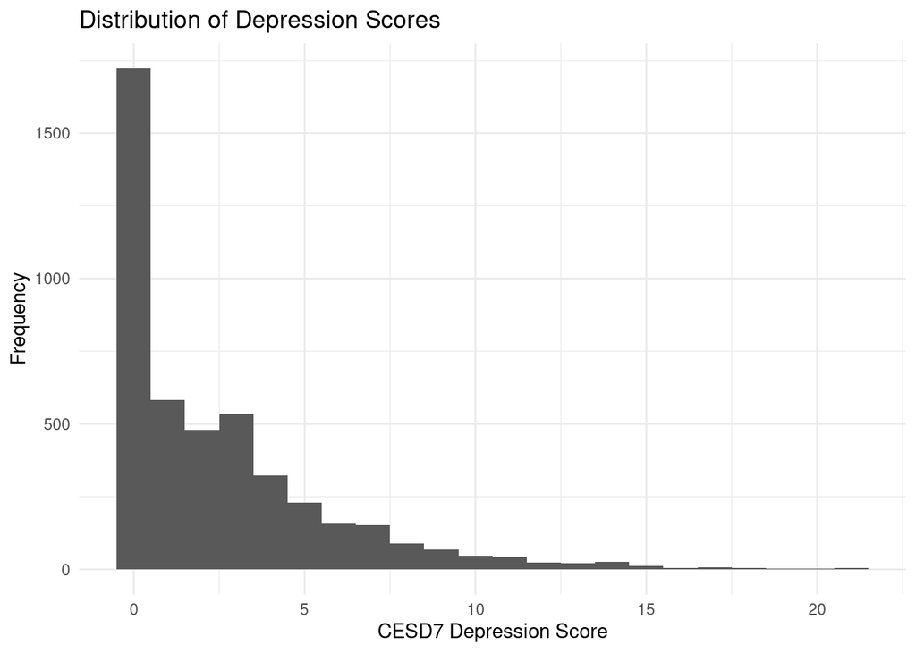

```r
ggplot(nsece_ps2_recode,
       aes(x = depression)) +
  geom_histogram(binwidth = 1) +
  labs(
    title = "Distribution of Depression Scores",
    x = "CESD7 Depression Score",
    y = "Frequency"
  ) +
  theme_minimal()
```

**Interpretation:** Depression score is an interval/ratio, discrete variable ranging from 0 to 21. Among the 4,537 respondents with non-missing depression scores, the mean score was approximately 2.52 and the median was 1. The standard deviation was approximately 3.22, and the interquartile range was 4. There were 655 observations with missing depression scores.

The distribution of depression scores is strongly right-skewed. Most respondents reported relatively low depression scores, while a smaller number had substantially higher scores, producing a long right tail. This skewness also helps explain why the mean (2.52) is higher than the median (1). Overall, depressive symptoms were relatively low for most respondents, although some respondents reported much higher levels of depressive symptoms.

### Staff Age

```r
# Variable type: Interval/Ratio + Discrete

# Descriptive statistics for staff age
staff_age_summary <-
  nsece_ps2_recode %>%
  summarise(
    n = sum(!is.na(staff_age)),
    missing = sum(is.na(staff_age)),
    mean = mean(staff_age, na.rm = TRUE),
    median = median(staff_age, na.rm = TRUE),
    sd = sd(staff_age, na.rm = TRUE),
    min = min(staff_age, na.rm = TRUE),
    max = max(staff_age, na.rm = TRUE),
    IQR = IQR(staff_age, na.rm = TRUE)
  )

staff_age_summary
```

```
##      n missing     mean median       sd min max IQR
## 1 4497     695 40.26618     38 13.63905  21  69  22
```

```r
#write_csv(staff_age_summary, "staff_age_summary.csv")
```

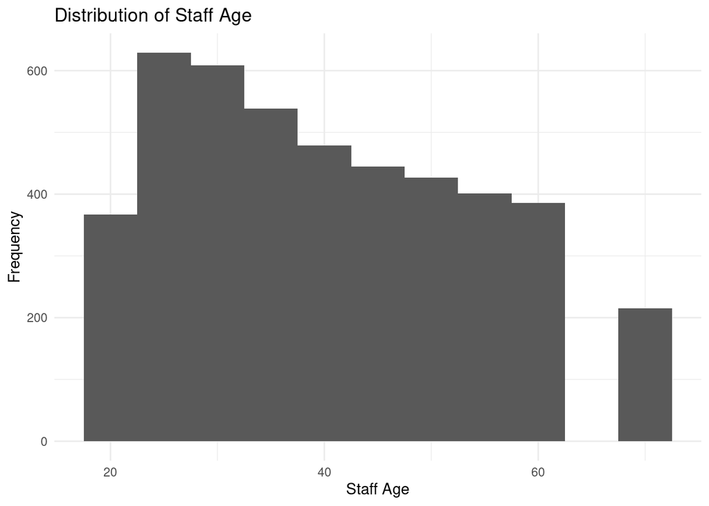

```r
# Histogram of staff age
nsece_ps2_recode %>%
  filter(!is.na(staff_age)) %>%
  ggplot(aes(x = staff_age)) +
  geom_histogram(binwidth = 5) +
  labs(
    title = "Distribution of Staff Age",
    x = "Staff Age",
    y = "Frequency"
  ) +
  theme_minimal()
```

**Interpretation:** Staff age is an interval/ratio, discrete variable because age has meaningful numerical differences and, in this dataset, is measured in whole years. Among the 4,497 respondents with available age information, the mean age was approximately 40.27 years, while the median was 38 years. Staff ages ranged from 21 to 69 years, with a standard deviation of approximately 13.64 years and an interquartile range of 22 years, indicating substantial variation in age among staff.

The histogram shows that staff were more concentrated among younger ages, particularly in their 20s and 30s, with frequencies generally declining at older ages. The distribution is not symmetric, which is also consistent with the mean being somewhat higher than the median. There were 695 observations with missing age information.

```r
# Categorized staff age: Ordinal + Discrete

# Frequency and percentage table
staff_age_table <-
  nsece_ps2_recode %>%
  count(staff_age_new) %>%
  mutate(proportion = (n / sum(n)) * 100)

staff_age_table
```

```
##       staff_age_new    n proportion
## 1 Between 20 and 40 2449   47.16872
## 2 Between 41 and 50  895   17.23806
## 3      More than 51 1153   22.20724
## 4              <NA>  695   13.38598
```

```r
glimpse(nsece_ps2_recode)
```

```
## Rows: 5,192
## Columns: 9
## $ hourly_wage   <dbl> NA, 8.653846, 4.444444, 10.000000, 8.500000, 15.000000, …
## $ staff_role    <fct> "(2) Teacher, instructor, or lead teacher", "(2) Teacher…
## $ race          <fct> (1) White Only, (1) White Only, (1) White Only, (1) Whit…
## $ education     <fct> "(6) Associate degree (AA, AS)", "(6) Associate degree (…
## $ birth_year    <dbl> 1975, 1973, 1976, 1960, 1998, 1960, 1965, 1986, 1968, 19…
## $ depression    <dbl> 4.000000, 0.000000, 17.000000, 14.000000, 3.000000, 3.00…
## $ staff_age     <dbl> 44, 46, 43, 59, 21, 59, 54, 33, 51, 24, 61, 44, 69, 47, …
## $ staff_age_new <fct> Between 41 and 50, Between 41 and 50, Between 41 and 50,…
## $ hr_wage_new   <fct> NA, Less than $10, Less than $10, Less than $10, Less th…
```

**Interpretation 2** The categorized staff age variable (staff_age_new) is ordinal and discrete because the age categories have a meaningful order. Staff between ages 20 and 40 represented the largest category, accounting for approximately 47.17% of all observations. Staff between ages 41 and 50 represented 17.24%, while those in the oldest category represented 22.21%. Approximately 13.39% of observations were missing age information. The frequency distribution therefore reinforces the pattern seen in the histogram: younger staff make up the largest portion of the workforce represented in the dataset.

### Hourly Wage

```r
# Variable type: Interval/Ratio + Continuous

# Descriptive statistics for hourly wage
hourly_wage_summary <-
  nsece_ps2_recode %>%
  summarise(
    n = sum(!is.na(hourly_wage)),
    missing = sum(is.na(hourly_wage)),
    mean = mean(hourly_wage, na.rm = TRUE),
    median = median(hourly_wage, na.rm = TRUE),
    sd = sd(hourly_wage, na.rm = TRUE),
    min = min(hourly_wage, na.rm = TRUE),
    max = max(hourly_wage, na.rm = TRUE),
    IQR = IQR(hourly_wage, na.rm = TRUE)
  )

hourly_wage_summary
```

```
##      n missing     mean   median       sd      min   max IQR
## 1 4270     922 15.33189 12.82526 10.65479 1.285714 107.5 6.5
```

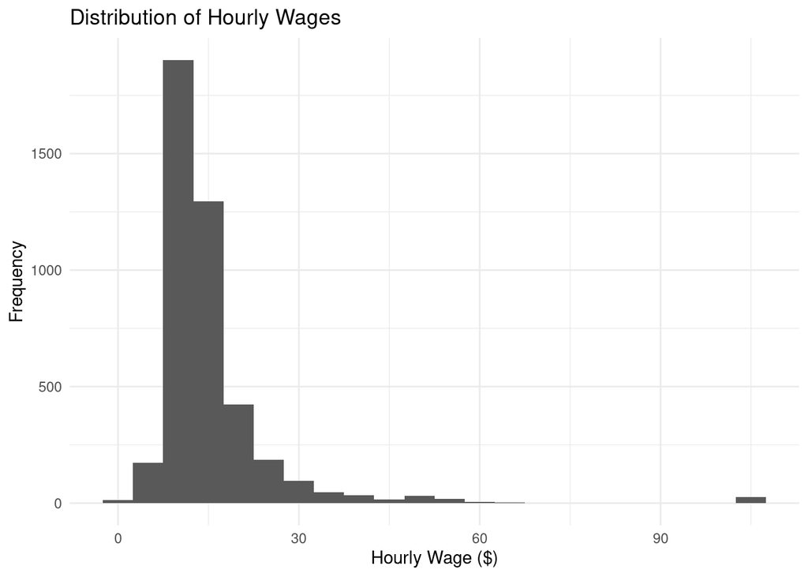

```r
# Histogram of hourly wage
nsece_ps2_recode %>%
  filter(!is.na(hourly_wage)) %>%
  ggplot(aes(x = hourly_wage)) +
  geom_histogram(binwidth = 5) +
  labs(
    title = "Distribution of Hourly Wages",
    x = "Hourly Wage ($)",
    y = "Frequency"
  ) +
  theme_minimal()
```

```r
# Categorized hourly wage: Ordinal + Discrete

# Frequency and percentage table
hr_wage_table <-
  nsece_ps2_recode %>%
  count(hr_wage_new) %>%
  mutate(proportion = (n / sum(n)) * 100)

hr_wage_table
```

```
##           hr_wage_new    n proportion
## 1       Less than $10 1088  20.955316
## 2 Between $11 and $20 2359  45.435285
## 3 Between $21 and $30  335   6.452234
## 4       More than $31  209   4.025424
## 5                <NA> 1201  23.131741
```

**Interpretation:** The categorized hourly wage variable (hr_wage_new) is ordinal and discrete because respondents are placed into wage categories that have a meaningful order. The largest category was workers earning between $11 and $20 per hour, representing approximately 45.44% of all observations. About 20.96% earned less than $10 per hour, while 6.45% earned between $21 and $30 and 4.03% earned more than $31. Approximately 23.13% of observations were missing from the categorized wage variable. Overall, the categorical distribution supports the pattern observed in the histogram, with most workers concentrated in the lower wage categories and relatively few workers in the higher wage categories.

# Question 2 — Prepare the Data for Linear Regression (2 points)

Create the derived variables needed to estimate a multiple linear regression model:

- Create **k - 1 binary variables for staff role** (`k` = number of categories). After examining the variable, choose a **reference group**.
- Create **k - 1 binary variables for race**. After examining the variable, choose a **reference group**.
- Create **k - 1 binary variables for educational attainment**. After examining the variable, choose a **reference group**.
- Create **k - 1 binary variables for staff age**. After examining the variable, choose a **reference group**.
- Create **k - 1 binary variables for hourly wage**. After examining the variable, choose a **reference group**.

## Staff Role Binary Variables

```r
# Staff role: 3 categories, so create k - 1 = 2 binary variables
# Reference group: Aide or assistant teacher

nsece_ps2_recode <-
  nsece_ps2_recode %>%
  mutate(
    teacher_d = ifelse(
      staff_role == "(2) Teacher, instructor, or lead teacher", 1, 0
    ),

    other_role_d = ifelse(
      staff_role == "(3) Other/undetermined", 1, 0
    )
  )

# Create readable table of binary-variable counts
staff_role_binary_table <-
  nsece_ps2_recode %>%
  summarise(
    `Teacher, Instructor, or Lead Teacher` = sum(teacher_d, na.rm = TRUE),
    `Other/Undetermined` = sum(other_role_d, na.rm = TRUE)
  )

knitr::kable(
  staff_role_binary_table,
  caption = "Number of Respondents Coded 1 for Each Staff Role Binary Variable"
)
```

Number of Respondents Coded 1 for Each Staff Role Binary Variable

| Teacher, Instructor, or Lead Teacher | Other/Undetermined |
| --- | --- |
| 3079 | 18 |

**Reference group:** Aide or assistant teacher.

## Race Binary Variables

```r
# Race: 4 categories, so create k - 1 = 3 binary variables
# Reference group: White Only

nsece_ps2_recode <-
  nsece_ps2_recode %>%
  mutate(
    black_d = ifelse(
      race == "(2) Black or African American Only", 1, 0
    ),

    asian_d = ifelse(
      race == "(3) Asian Only", 1, 0
    ),

    other_race_d = ifelse(
      race == "(8) Other", 1, 0
    )
  )

# Examine the new binary variables
race_binary_table <-
  nsece_ps2_recode %>%
  summarise(
    `Black or African American Only` = sum(black_d == 1, na.rm = TRUE),
    `Asian Only` = sum(asian_d == 1, na.rm = TRUE),
    `Other` = sum(other_race_d == 1, na.rm = TRUE)
  )

knitr::kable(
  race_binary_table,
  caption = "Number of Respondents Coded 1 for Each Race Binary Variable"
)
```

Number of Respondents Coded 1 for Each Race Binary Variable

| Black or African American Only | Asian Only | Other |
| --- | --- | --- |
| 991 | 210 | 215 |

**Reference group:** White Only

## Educational Attainment Binary Variables

```r
# Educational attainment: 7 categories, so create k - 1 = 6 binary variables
# Reference group: Some college credit but no degree

nsece_ps2_recode <-
  nsece_ps2_recode %>%
  mutate(
    less_hs_d = ifelse(
      education == "(1) Less than High School", 1, 0
    ),

    ged_d = ifelse(
      education == "(3) GED or high school equivalency", 1, 0
    ),

    hs_grad_d = ifelse(
      education == "(4) High school graduate", 1, 0
    ),

    associate_d = ifelse(
      education == "(6) Associate degree (AA, AS)", 1, 0
    ),

    bachelor_d = ifelse(
      education == "(7) Bachelor's degree (BA, BS, AB)", 1, 0
    ),

    graduate_d = ifelse(
      education == "(8) Graduate or professional degree", 1, 0
    )
  )

# Create readable table to examine the new binary variables
education_binary_table <-
  nsece_ps2_recode %>%
  summarise(
    `Less than High School` = sum(less_hs_d == 1, na.rm = TRUE),
    `GED or High School Equivalency` = sum(ged_d == 1, na.rm = TRUE),
    `High School Graduate` = sum(hs_grad_d == 1, na.rm = TRUE),
    `Associate Degree` = sum(associate_d == 1, na.rm = TRUE),
    `Bachelor's Degree` = sum(bachelor_d == 1, na.rm = TRUE),
    `Graduate or Professional Degree` = sum(graduate_d == 1, na.rm = TRUE)
  )

knitr::kable(
  education_binary_table,
  caption = "Number of Respondents Coded 1 for Each Educational Attainment Binary Variable"
)
```

Number of Respondents Coded 1 for Each Educational Attainment Binary Variable

| Less than High School | GED or High School Equivalency | High School Graduate | Associate Degree | Bachelor’s Degree | Graduate or Professional Degree |
| --- | --- | --- | --- | --- | --- |
| 85 | 126 | 769 | 834 | 1168 | 424 |

**Reference group:** Some college credit but no degree

## Staff Age Binary Variables

```r
# Staff age: 3 categories, so create k - 1 = 2 binary variables
# Reference group: Between 20 and 40

nsece_ps2_recode <-
  nsece_ps2_recode %>%
  mutate(
    age_41_50_d = ifelse(
      staff_age_new == "Between 41 and 50", 1, 0
    ),

    age_51plus_d = ifelse(
      staff_age_new == "More than 51", 1, 0
    )
  )

# Create readable table of binary-variable counts
staff_age_binary_table <-
  nsece_ps2_recode %>%
  summarise(
    `Between 41 and 50` = sum(age_41_50_d, na.rm = TRUE),
    `More than 51` = sum(age_51plus_d, na.rm = TRUE)
  )

knitr::kable(
  staff_age_binary_table,
  caption = "Number of Respondents Coded 1 for Each Staff Age Binary Variable"
)
```

Number of Respondents Coded 1 for Each Staff Age Binary Variable

| Between 41 and 50 | More than 51 |
| --- | --- |
| 895 | 1153 |

**Reference group:** Between 20 and 40

## Hourly Wage Binary Variables

```r
# Hourly wage: 4 categories, so create k - 1 = 3 binary variables
# Reference group: Between $11 and $20

nsece_ps2_recode <-
  nsece_ps2_recode %>%
  mutate(
    wage_under_10_d = ifelse(
      hr_wage_new == "Less than $10", 1, 0
    ),

    wage_21_30_d = ifelse(
      hr_wage_new == "Between $21 and $30", 1, 0
    ),

    wage_31plus_d = ifelse(
      hr_wage_new == "More than $31", 1, 0
    )
  )

# Create readable table of binary-variable counts
hourly_wage_binary_table <-
  nsece_ps2_recode %>%
  summarise(
    `Less than $10` = sum(wage_under_10_d, na.rm = TRUE),
    `Between $21 and $30` = sum(wage_21_30_d, na.rm = TRUE),
    `More than $31` = sum(wage_31plus_d, na.rm = TRUE)
  )

knitr::kable(
  hourly_wage_binary_table,
  caption = "Number of Respondents Coded 1 for Each Hourly Wage Binary Variable"
)
```

Number of Respondents Coded 1 for Each Hourly Wage Binary Variable

| Less than $10 | Between $21 and $30 | More than $31 |
| --- | --- | --- |
| 1088 | 335 | 209 |

**Reference group:** Between $11 and $20

# Question 3 — Estimate the OLS Regression Model (4 points)

Estimate an OLS regression model to examine factors associated with depression among center-based early care and education staff.

The model specified in the assignment is:

$$\text{Depression} =
\beta_0 +
\beta(\text{hourly wage}) +
\beta(\text{staff role}) +
\beta(\text{staff age}) +
\beta(\text{education level categories}) +
\beta(\text{race categories}) +
\varepsilon$$

## Estimate the Model

```r
# Estimate the OLS regression model
depression_model <- lm(
  depression ~
    wage_under_10_d +
    wage_21_30_d +
    wage_31plus_d +
    teacher_d +
    other_role_d +
    age_41_50_d +
    age_51plus_d +
    less_hs_d +
    ged_d +
    hs_grad_d +
    associate_d +
    bachelor_d +
    graduate_d +
    black_d +
    asian_d +
    other_race_d,
  data = nsece_ps2_recode
)

# View regression results
#summary(depression_model)

# Create a readable regression results table
regression_table <-
  as.data.frame(summary(depression_model)$coefficients) %>%
  rownames_to_column("Variable") %>%
  rename(
    Estimate = Estimate,
    `Standard Error` = `Std. Error`,
    `t-value` = `t value`,
    `p-value` = `Pr(>|t|)`
  ) %>%
  mutate(
    Variable = recode(
      Variable,
      "(Intercept)" = "Intercept",
      "wage_under_10_d" = "Less than $10/hour",
      "wage_21_30_d" = "$21–$30/hour",
      "wage_31plus_d" = "More than $31/hour",
      "teacher_d" = "Teacher, Instructor, or Lead Teacher",
      "other_role_d" = "Other/Undetermined Staff Role",
      "age_41_50_d" = "Age 41–50",
      "age_51plus_d" = "Age 51+",
      "less_hs_d" = "Less than High School",
      "ged_d" = "GED or High School Equivalency",
      "hs_grad_d" = "High School Graduate",
      "associate_d" = "Associate Degree",
      "bachelor_d" = "Bachelor's Degree",
      "graduate_d" = "Graduate or Professional Degree",
      "black_d" = "Black or African American Only",
      "asian_d" = "Asian Only",
      "other_race_d" = "Other Race"
    ),
    across(where(is.numeric), ~ round(.x, 3))
  )

knitr::kable(
  regression_table,
  caption = "OLS Regression Results: Factors Associated with Depression"
)
```

OLS Regression Results: Factors Associated with Depression

| Variable | Estimate | Standard Error | t-value | p-value |
| --- | --- | --- | --- | --- |
| Intercept | 3.071 | 0.150 | 20.532 | 0.000 |
| Less than $10/hour | 0.163 | 0.137 | 1.193 | 0.233 |
| $21–$30/hour | -0.030 | 0.213 | -0.141 | 0.888 |
| More than $31/hour | 0.003 | 0.269 | 0.012 | 0.990 |
| Teacher, Instructor, or Lead Teacher | 0.250 | 0.121 | 2.061 | 0.039 |
| Other/Undetermined Staff Role | 0.910 | 0.961 | 0.947 | 0.344 |
| Age 41–50 | -0.443 | 0.151 | -2.938 | 0.003 |
| Age 51+ | -1.289 | 0.137 | -9.385 | 0.000 |
| Less than High School | -0.077 | 0.450 | -0.172 | 0.863 |
| GED or High School Equivalency | -0.066 | 0.359 | -0.183 | 0.855 |
| High School Graduate | -0.470 | 0.176 | -2.668 | 0.008 |
| Associate Degree | -0.495 | 0.174 | -2.843 | 0.004 |
| Bachelor’s Degree | -0.236 | 0.162 | -1.464 | 0.143 |
| Graduate or Professional Degree | -0.358 | 0.231 | -1.550 | 0.121 |
| Black or African American Only | 0.102 | 0.137 | 0.741 | 0.459 |
| Asian Only | 0.124 | 0.267 | 0.464 | 0.643 |
| Other Race | 0.437 | 0.249 | 1.758 | 0.079 |

## Interpret Statistically Significant Coefficients

Interpret the coefficient estimates for each statistically significant independent variable.

**Answer:** Holding the other variables in the model constant, teachers, instructors, or lead teachers had depression scores approximately 0.25 points higher than aides or assistant teachers, the reference group. This association was statistically significant (p = 0.039).

Staff between ages 41 and 50 had depression scores approximately 0.44 points lower than staff between ages 20 and 40, the reference group (p = 0.003). Staff age 51 or older had depression scores approximately 1.29 points lower than the reference group (p < 0.001).

For educational attainment, high school graduates had depression scores approximately 0.47 points lower than respondents with some college credit but no degree, the reference group (p = 0.008). Respondents with an associate degree had depression scores approximately 0.49 points lower than the same reference group (p = 0.004).

None of the hourly wage or race binary variables were statistically significant at the 0.05 level. The remaining staff-role and educational-attainment variables were also not statistically significant.

## Interpret Overall Model Fit

Interpret the overall model fit, including **R²** and **adjusted R²**.

**Answer:** The model had an R² of approximately 0.034, indicating that the independent variables included in the model explain about 3.4% of the variation in depression scores among the staff included in the regression. The adjusted R² was approximately 0.029, meaning that after accounting for the number of predictors in the model, approximately 2.9% of the variation in depression scores was explained.

Although the amount of explained variation is relatively small, the overall regression model was statistically significant (F = 7.637, p < 0.001). This indicates that the predictors, considered together, are significantly associated with depression scores, even though the model explains only a small portion of the overall variation in depression.

## Conclusions

What conclusions can you draw about the factors associated with depression among center-based early care and education staff?

**Answer:** The results suggest that staff role, age, and educational attainment are associated with depression scores among center-based early care and education staff. Teachers, instructors, or lead teachers had slightly higher depression scores than aides or assistant teachers, while older staff generally had lower depression scores than staff ages 20–40. In particular, staff age 51 or older had substantially lower predicted depression scores. Educational attainment was also associated with depression for some groups, with high school graduates and respondents with associate degrees having lower depression scores than respondents with some college credit but no degree.

In contrast, hourly wage and race were not statistically significantly associated with depression in this model. Although the model was statistically significant overall, it explained only about 3.4% of the variation in depression scores, suggesting that much of the variation in depression is associated with factors not included in this analysis.

Overall, the findings indicate that certain demographic and employment characteristics are associated with depression among early care and education staff, particularly age, staff role, and some levels of educational attainment. However, these results represent associations rather than causal relationships and should not be interpreted as evidence that these characteristics directly cause differences in depression.

## Diagnostic Plots

Create:

1. A **residual plot**
2. A **histogram of the model residuals**

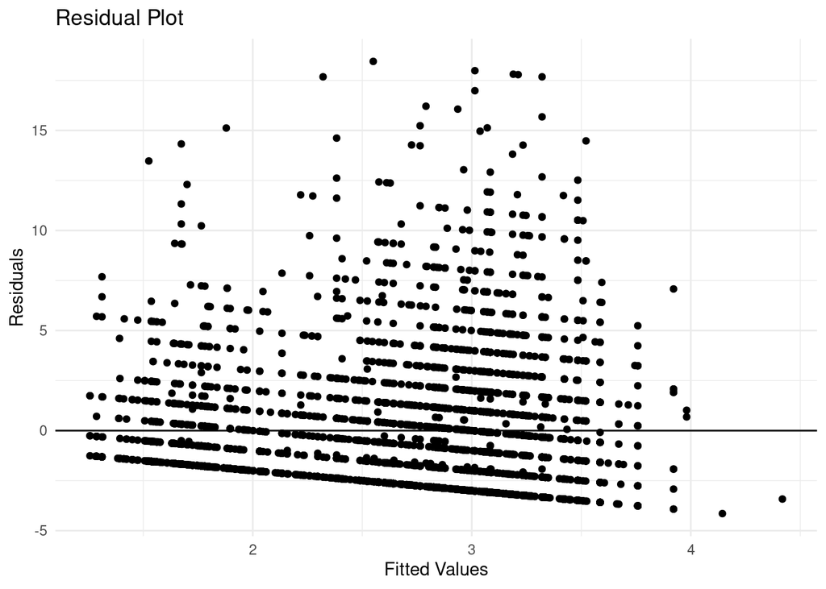

```r
# Residual plot
# Create a dataset with fitted values and residuals
diagnostic_data <- data.frame(
  fitted_values = fitted(depression_model),
  residuals = resid(depression_model)
)

# Residual plot
ggplot(diagnostic_data,
       aes(x = fitted_values, y = residuals)) +
  geom_point() +
  geom_hline(yintercept = 0) +
  labs(
    title = "Residual Plot",
    x = "Fitted Values",
    y = "Residuals"
  ) +
  theme_minimal()
```

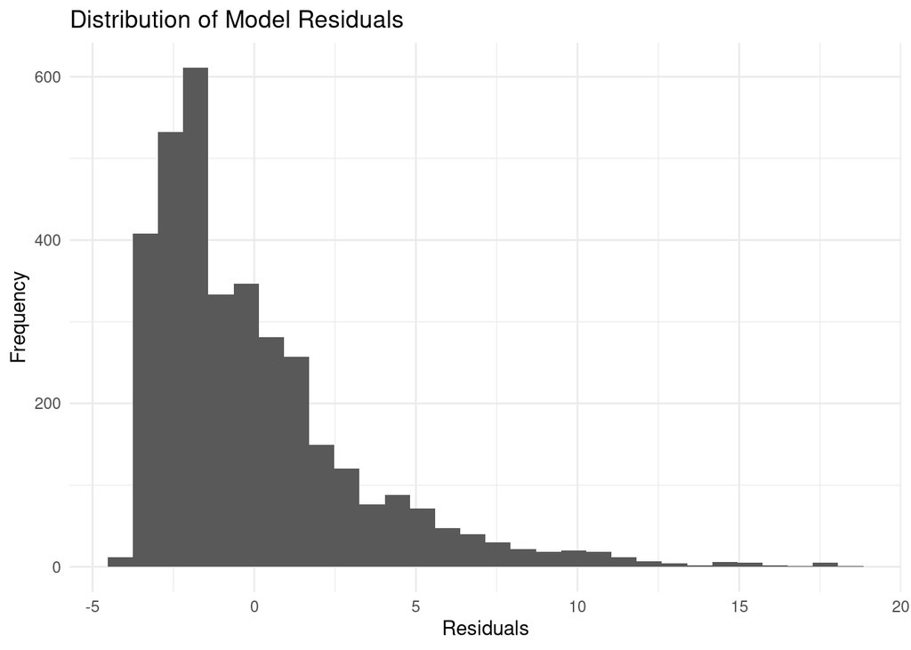

```r
# Histogram of residuals
# Histogram of residuals
ggplot(diagnostic_data,
       aes(x = residuals)) +
  geom_histogram(bins = 30) +
  labs(
    title = "Distribution of Model Residuals",
    x = "Residuals",
    y = "Frequency"
  ) +
  theme_minimal()
```

Do these diagnostic plots suggest that the assumptions of **linearity, homoscedasticity, and normality** are reasonably met? What hypotheses do you have about why the plots look the way they do?

**Answer:** The diagnostic plots suggest that the assumptions of the OLS regression model are not fully met. In the residual plot, the residuals are not evenly distributed around zero, and the spread of the residuals varies across the fitted values. This suggests that the assumptions of linearity and homoscedasticity may not be fully satisfied.

The histogram of the residuals also shows a strongly right-skewed distribution rather than an approximately normal distribution. Most residuals are concentrated at lower values, while a smaller number of observations have very large positive residuals. Therefore, the normality assumption does not appear to be well satisfied.

One possible explanation is the nature of the dependent variable. Depression is measured using the CESD7 score, which ranges from 0 to 21, and the earlier descriptive analysis showed that most respondents had relatively low depression scores while a smaller number had much higher scores. Because the dependent variable itself is discrete, bounded, and strongly right-skewed, the residuals from the OLS model may also exhibit an unusual and right-skewed pattern.